# PlasticDaphnia: Nicola’s exposure PCoA ordinations: Daphnia’s microbiome

```r
library(phyloseq)
library(vegan)
library(ggplot2)
library(ggpubr)
library(data.table)
library(BiocManager)
library(microbiome)
library(knitr)
#install.packages("patchwork")
library(patchwork)
```

Load ps-object and metadata

```r
#Load phyloseq (rarefied)
ps_mic = readRDS("/Users/u0145079/Library/CloudStorage/OneDrive-KULeuven/Desktop/PlasticDaphnia/Exposure-Niki/tables/phyloseq/decontam/ps_rare_daphnia_decontam.rds")

#load meta
meta = read.csv("/Users/u0145079/Library/CloudStorage/OneDrive-KULeuven/Desktop/PlasticDaphnia/Exposure-Niki/tables/decontaminated_set/merged_meta.csv",row.names = 1)
```

Load metadata into ps

```r
# Extract common sample IDs
common_sample_ids <- intersect(sample_names(ps_mic), row.names(meta))
# Subset metadata to include only common sample IDs
filtered_meta <- meta[common_sample_ids, ]
# Assign filtered metadata as sample_data for ps_bac
sample_data(ps_mic) <- filtered_meta
ps_mic <- subset_samples(ps_mic, Exposure_time !="Pre-Env") #remove 2 extra env-samples
```

```r
# Perform permutation test
permutest(dispersion_test, permutations = 999)#0.163
```

```
Permutation test for homogeneity of multivariate dispersions
Permutation: free
Number of permutations: 999

Response: Distances
          Df  Sum Sq   Mean Sq      F N.Perm Pr(>F)
Groups     1 0.01542 0.0154211 2.0646    999  0.157
Residuals 65 0.48551 0.0074693
```

Are pre-exposure controls the same as exposure controls (jars without plastic added)? PERMANOVA between Exposure control and pre-exposure control If significant, we leave it, if not -> Merge then into “CONTROL”

```r
subset_phyloseq <- subset_samples(ps_mic, Exposure_time =="Pre" | Exposure_time =="Post" & Plastic == "C" & Age == "Adult")
filtered_meta <- data.frame(sample_data(subset_phyloseq))
bray <- vegdist(as.data.frame(t(otu_table(subset_phyloseq)), method="bray")) #creating dissimilarity matrix with vegdist using bray curtis

permanova_result <- adonis2(bray~ Exposure_time, data = filtered_meta, na.action = na.omit) #0.004 **

#Dispersion
dispersion_test <- betadisper(bray, filtered_meta$Exposure_time,bias.adjust =TRUE)
# Perform permutation test
permutest(dispersion_test, permutations = 999)#0.179
```

Which community is richer?

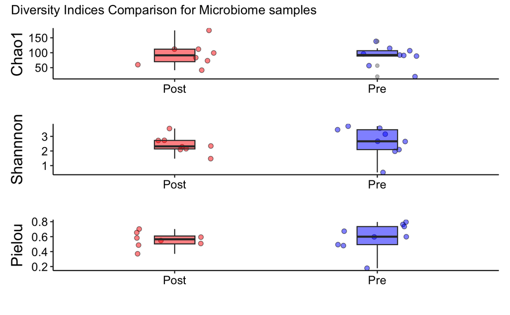

Yes there is a statistically significant difference between pre-exposure indv. and those not exposed at all to plastic. Likely due to the uptake of bacterioplankton from the surrounding water. The clone controls microbiome changed over the course of exposure in the absence of MPs. There is no difference in the richness.

Is there a difference between BP and DG post-exposure communities? CONTROLS - Non-plastic exposed samples

```r
subset_phyloseq <- subset_samples(ps_mic, Pond == "BP" & Category != "Daphnia: Post-Long-exposure (selected survivals)" & Plastic_presence == "No" | Pond == "DG" & Category != "Daphnia: Post-Long-exposure (selected survivals)" & Plastic_presence == "No")
filtered_meta <- data.frame(sample_data(subset_phyloseq))
bray <- vegdist(as.data.frame(t(otu_table(subset_phyloseq)), method="bray")) #creating dissimilarity matrix with vegdist using bray curtis

permanova_result <- adonis2(bray~ Pond, data = filtered_meta, na.action = na.omit) #0.001 ***
permanova_result
#Dispersion
dispersion_test <- betadisper(bray, filtered_meta$Pond,bias.adjust =TRUE)
# Perform permutation test
permutest(dispersion_test, permutations = 999)#0.834
```

```
ANSWER: Yes, there is a difference between DG and BP communities in the absence of MPs exposure
```

Is there a difference between BP and DG post-exposure communities? WITH Plastics

```r
subset_phyloseq <- subset_samples(ps_mic, Pond == "BP" & Category != "Daphnia: Post-Long-exposure (selected survivals)" & Plastic_presence == "Yes" | Pond == "DG" & Category != "Daphnia: Post-Long-exposure (selected survivals)" & Plastic_presence == "Yes")
filtered_meta <- data.frame(sample_data(subset_phyloseq))
bray <- vegdist(as.data.frame(t(otu_table(subset_phyloseq)), method="bray")) #creating dissimilarity matrix with vegdist using bray curtis

permanova_result <- adonis2(bray~ Pond, data = filtered_meta, na.action = na.omit) #0.001 ***
permanova_result
#Dispersion
dispersion_test <- betadisper(bray, filtered_meta$Pond,bias.adjust =TRUE)
# Perform permutation test
permutest(dispersion_test, permutations = 999)#0.206
```

```
ANSWER: Yes, there is a difference between DG and BP communities in the presence of MPs
```

BLAUWE POORT:

[output not shown]

```r
bray <- vegdist(as.data.frame(t(otu_table(subset_phyloseq)), method="bray")) #creating dissimilarity matrix with vegdist using bray curtis
bray <- vegdist(as.data.frame(t(otu_table(subset_phyloseq)), method="bray")) #creating dissimilarity matrix with vegdist using bray curtis
permanova_result <- adonis2(bray~ Plastic_presence, data = filtered_meta, na.action = na.omit) #0.016 *
permanova_result
```

```
Permutation test for adonis under reduced model
Terms added sequentially (first to last)
Permutation: free
Number of permutations: 999

adonis2(formula = bray ~ Plastic_presence, data = filtered_meta, na.action = na.omit)
                 Df SumOfSqs      R2      F Pr(>F)
Plastic_presence  1   0.7468 0.05147 2.3334  0.023 *
Residual         43  13.7613 0.94853
Total            44  14.5081 1.00000
---
Signif. codes:  0 ‘***’ 0.001 ‘**’ 0.01 ‘*’ 0.05 ‘.’ 0.1 ‘ ’ 1
```

```r
#Dispersion
dispersion_test <- betadisper(bray, filtered_meta$Plastic_presence,bias.adjust =TRUE)
# Perform permutation test
permutest(dispersion_test, permutations = 999)#0.065 .
```

```
Permutation test for homogeneity of multivariate dispersions
Permutation: free
Number of permutations: 999

Response: Distances
          Df  Sum Sq  Mean Sq      F N.Perm Pr(>F)
Groups     1 0.05585 0.055847 3.6563    999  0.066 .
Residuals 43 0.65679 0.015274
---
Signif. codes:  0 ‘***’ 0.001 ‘**’ 0.01 ‘*’ 0.05 ‘.’ 0.1 ‘ ’ 1
```

BLAUWE POORT:

```
    ○ Only adults
    ○ Post-exposure only
    ○ Control(NO MPs in the jar) vs Plastics
    ○ If not significant then test for each plastic separetly
```

```r
bray <- vegdist(as.data.frame(t(otu_table(subset_phyloseq)), method="bray")) #creating dissimilarity matrix with vegdist using bray curtis
bray <- vegdist(as.data.frame(t(otu_table(subset_phyloseq)), method="bray")) #creating dissimilarity matrix with vegdist using bray curtis
permanova_result <- adonis2(bray~ Plastic_presence, data = filtered_meta, na.action = na.omit) #0.016 *
permanova_result
```

```
Permutation test for adonis under reduced model
Terms added sequentially (first to last)
Permutation: free
Number of permutations: 999

adonis2(formula = bray ~ Plastic_presence, data = filtered_meta, na.action = na.omit)
                 Df SumOfSqs      R2      F Pr(>F)
Plastic_presence  1   0.7468 0.05147 2.3334  0.014 *
Residual         43  13.7613 0.94853
Total            44  14.5081 1.00000
---
Signif. codes:  0 ‘***’ 0.001 ‘**’ 0.01 ‘*’ 0.05 ‘.’ 0.1 ‘ ’ 1
```

```r
#Dispersion
dispersion_test <- betadisper(bray, filtered_meta$Plastic_presence,bias.adjust =TRUE)
# Perform permutation test
permutest(dispersion_test, permutations = 999)#0.065 .
```

```
Permutation test for homogeneity of multivariate dispersions
Permutation: free
Number of permutations: 999

Response: Distances
          Df  Sum Sq  Mean Sq      F N.Perm Pr(>F)
Groups     1 0.05585 0.055847 3.6563    999  0.057 .
Residuals 43 0.65679 0.015274
---
Signif. codes:  0 ‘***’ 0.001 ‘**’ 0.01 ‘*’ 0.05 ‘.’ 0.1 ‘ ’ 1
```

DE GAVERS:

[output not shown]

```r
subset_phyloseq <- subset_samples(ps_mic, Pond == "DG" & Age == "Adult" & Category != "Daphnia: Post-Long-exposure (selected survivals)"| Exposure_time == "Pre")
filtered_meta <- data.frame(sample_data(subset_phyloseq))
bray <- vegdist(as.data.frame(t(otu_table(subset_phyloseq)), method="bray")) #creating dissimilarity matrix with vegdist using bray curtis

permanova_result <- adonis2(bray~ Plastic_presence, data = filtered_meta, na.action = na.omit) #0.002 **
permanova_result
#Dispersion
dispersion_test <- betadisper(bray, filtered_meta$Plastic_presence,bias.adjust =TRUE)
# Perform permutation test
permutest(dispersion_test, permutations = 999)#0.72 .
```

What are significant effects? All samples

```r
subset_phyloseq <- subset_samples(ps_mic, Exposure_time !="Pre" & Plastic != "C")
filtered_meta <- data.frame(sample_data(subset_phyloseq))
bray <- vegdist(as.data.frame(t(otu_table(subset_phyloseq)), method="bray")) #creating dissimilarity matrix with vegdist using bray curtis

permanova_result <- adonis2(bray~ Pond*Clone*Plastic*Age, data = filtered_meta, na.action = na.omit)
permanova_result_df = data.frame(permanova_result)
```

Check for equality of variances:

```r
"Pond"
dispersion_test <- betadisper(bray, filtered_meta$Pond,bias.adjust =TRUE)
# Perform permutation test
permutest(dispersion_test, permutations = 999)#0.247

"Age"
dispersion_test <- betadisper(bray, filtered_meta$Age,bias.adjust =TRUE)
# Perform permutation test
permutest(dispersion_test, permutations = 999)#0.007 **
```

```r
# Add envfit vectors
p + geom_segment(data = scores_envfit,
                 aes(x = 0, y = 0, xend = PCoA1, yend = PCoA2),
                 arrow = arrow(length = unit(0.3, "cm")), color = "grey") +
  geom_text(data = scores_envfit,
            aes(x = PCoA1, y = PCoA2, label = rownames(scores_envfit)),
            color = "black", vjust = 1.5)
```

[output not shown]

```
[1] "Cluster quality index silhouette"
[1] -0.02941234
[1] "Among the top 100 covarying taxa, 3 are significant."
[1] "Aeromonas_NA"
[1] "Massilia_NA.2"
[1] "Gemmata_NA.2"
```

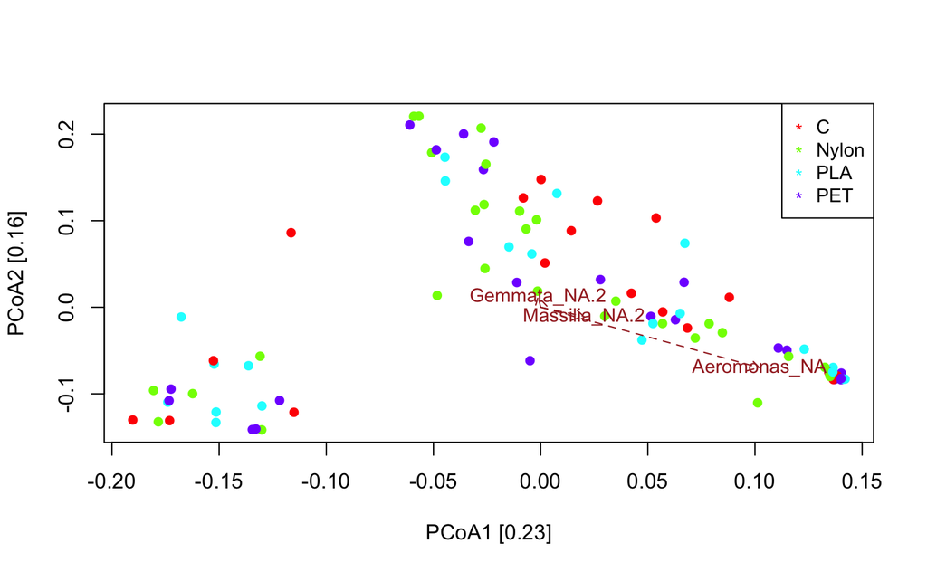

```r
seqPCoA(filtered_abundance,groups=meta_data$Plastic,topTaxa=100,arrowFactor=0.002)
```

What are significant effects? Blauwe Poort

```r
subset_phyloseq <- subset_samples(ps_mic, Exposure_time !="Pre" & Plastic != "C" & Pond == "BP")
filtered_meta <- data.frame(sample_data(subset_phyloseq))
bray <- vegdist(as.data.frame(t(otu_table(subset_phyloseq)), method="bray")) #creating dissimilarity matrix with vegdist using bray curtis

permanova_result <- adonis2(bray~ Clone*Plastic*Age, data = filtered_meta, na.action = na.omit)
permanova_result_df = data.frame(permanova_result)
```

```r
"Age"
dispersion_test <- betadisper(bray, filtered_meta$Age,bias.adjust =TRUE)
# Perform permutation test
permutest(dispersion_test, permutations = 999)#0.059 **
```

What are significant effects? De Gavers

```r
subset_phyloseq <- subset_samples(ps_mic, Exposure_time !="Pre" & Plastic != "C" & Pond == "DG")
filtered_meta <- data.frame(sample_data(subset_phyloseq))
bray <- vegdist(as.data.frame(t(otu_table(subset_phyloseq)), method="bray")) #creating dissimilarity matrix with vegdist using bray curtis

permanova_result <- adonis2(bray~ Clone*Plastic*Age, data = filtered_meta, na.action = na.omit)
permanova_result_df = data.frame(permanova_result)
```